# Sentiment Analysis

Chase Dawson

7/15/2020

```r
source(here::here("src", "load_data.R"));
source(here::here("src", "sentiment_analysis.R"))
```

## Useful Functions

```r
remove_words <- function(text, words) {
  pattern <- paste(words, collapse = "|");
  text <- str_replace_all(text, pattern, "");
  return(text);
}

radar <- function(sentiments, race, res_type) {
  group_mean <- dplyr::as_data_frame(sentiments) %>%
  filter(racial_group == race & response_type == res_type) %>%
  select(c("anger",
           "anticipation",
           "disgust",
           "fear",
           "joy",
           "negative",
           "positive",
           "sadness",
           "surprise",
           "trust")) %>%
  summarise_all(mean)

group_mean_melted <- melt(group_mean)
plot_data <- rbind(rep(max(group_mean_melted$value), 10), rep(min(group_mean_melted$value), 10), group_mean);

radarchart(plot_data,
           cglcol = "grey",
           cglty = 1);
}

radar2 <- function(sentiments, group1, group2, title = "Sentiment Analysis Results") {
  group1_mean <- dplyr::as_data_frame(sentiments) %>%
  filter(racial_group == group1[1] & response_type == group1[2]) %>%
  select(c("anger",
           "anticipation",
           "disgust",
           "fear",
           "joy",
           "negative",
           "positive",
           "sadness",
           "surprise",
           "trust")) %>%
  summarise_all(mean)

  group2_mean <- dplyr::as_data_frame(sentiments) %>%
  filter(racial_group == group2[1] & response_type == group2[2]) %>%
  select(c("anger",
           "anticipation",
           "disgust",
           "fear",
           "joy",
           "negative",
           "positive",
           "sadness",
           "surprise",
           "trust")) %>%
  summarise_all(mean)

  # combine repsonses
  groups <- rbind(group1_mean, group2_mean)
  rownames(groups) <- c(group1[3], group2[3])

  # get min and max for plotting
  groups_melted <- melt(groups)
  minval <- min(groups_melted$value)
  maxval <- max(groups_melted$value)

  plot_data <- rbind(rep(maxval, 10), rep(minval, 10), groups)

  colors <- c("#e57200", "#232d4b")

  radarchart(plot_data,
             cglcol = "grey", # color of net
             cglty = 1, # net line type
             pcol = colors, # line color
             cglwd = 1, # net width,
             plwd = 3, # line width
             plty = 1, # plot line type
  )
  legend(x= 1, y= 1, legend = rownames(plot_data)[-c(1,2)], bty = "n", pch = 20, col = colors );
  title(main = title);
}
```

## Removing biased words

Words referring to race are biased within the sentiment libraries. For example, within the NRC lexicon, "black" and "negro" are associated with the negative and sadness sentiments, while "white" is associated with the anticipation, joy, positive, and trust sentiments.

```r
nrc_sentiments <- get_sentiments("nrc");
nrc_sentiments %>% filter(word == "black" | word == "negro" | word == "white")
```

```
## # A tibble: 8 x 2
##   word  sentiment
##   <chr> <chr>
## 1 black negative
## 2 black sadness
## 3 negro negative
## 4 negro sadness
## 5 white anticipation
## 6 white joy
## 7 white positive
## 8 white trust
```

These words are removed from the text before sentiments are analyzed to mitigate racial bias.

```r
words <- c("white", "black", "negro");
s32$text <- remove_words(s32$text, words);
```

## Computing Sentiments

The Bing and Afinn lexicons compute sentiments by associated a word with positivity or negativity. Bing classifies words in a binary fasion as positive or negative, and Afinn ranks a word on a scale from -5 to +5 with -5 being the most negative and +5 being the most positive.

Computing the overall sentiment of a response varies by the underlying lexicon. For Bing, the overall sentiment is computed by subtracting the number of positive words by the number of negative words. For Afinn, the overall sentiment is computed by summing the sentiment values for individual words.

```r
tidy_s32 <- s32 %>%
  unnest_tokens(word, text);

s32_bing <- tidy_s32 %>%
  inner_join(get_sentiments('bing')) %>%
  group_by(index, racial_group, response_type, outfits, sentiment) %>%
  count() %>%
  spread(sentiment, n, fill = 0) %>%
  mutate(sentiment = positive - negative);
s32_afinn <- tidy_s32 %>%
  inner_join(get_sentiments('afinn')) %>%
  group_by(index, racial_group, response_type, outfits) %>%
  summarise(sentiment = sum(value));
```

## Comparing Sentiments Across Groups

Compare BING sentiments of long responses for white and Black soldiers.

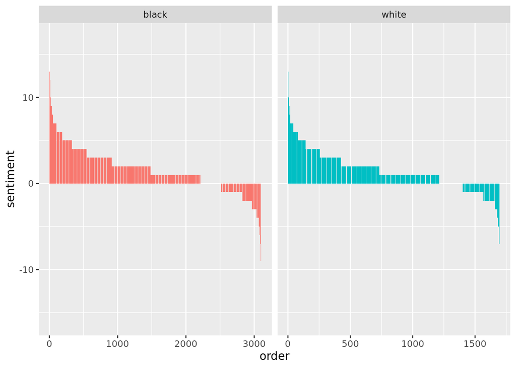

```r
black_long <- s32_bing %>%
  filter(racial_group == "black" & response_type == "long") %>%
  arrange(desc(sentiment));
black_long$order <- 1:nrow(black_long);

white_long <- s32_bing %>%
  filter(racial_group == "white" & response_type == "long") %>%
  arrange(desc(sentiment));
white_long$order <- 1:nrow(white_long);

rbind(black_long, white_long) %>%
ggplot(., aes(x = order, y = sentiment, fill = racial_group)) +
geom_col(show.legend = FALSE) +
facet_wrap(~racial_group, ncol = 2, scales = "free_x")
```

Compare BING sentiments of long responses for white segregationists and integrationist soldiers.

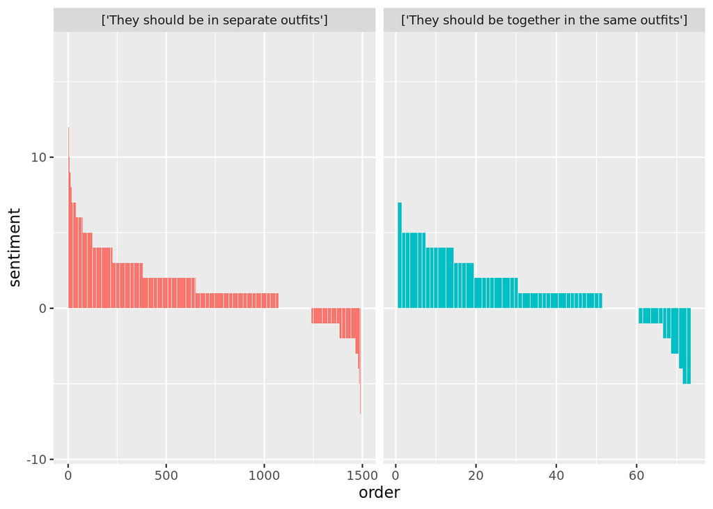

```r
group1 <- s32_bing %>%
  filter(racial_group == "white" & response_type == "long" & outfits == "['They should be in separate outfits']") %>%
  arrange(desc(sentiment));
group1$order <- 1:nrow(group1);

group2 <- s32_bing %>%
  filter(racial_group == "white" & response_type == "long" & outfits == "['They should be together in the same outfits']") %>%
  arrange(desc(sentiment));
group2$order <- 1:nrow(group2);

rbind(group1, group2) %>%
ggplot(., aes(x = order, y = sentiment, fill = outfits)) +
geom_col(show.legend = FALSE) +
facet_wrap(~outfits, ncol = 2, scales = "free_x")
```

Compare BING sentiments of short responses for white segregationists and integrationist soldiers.

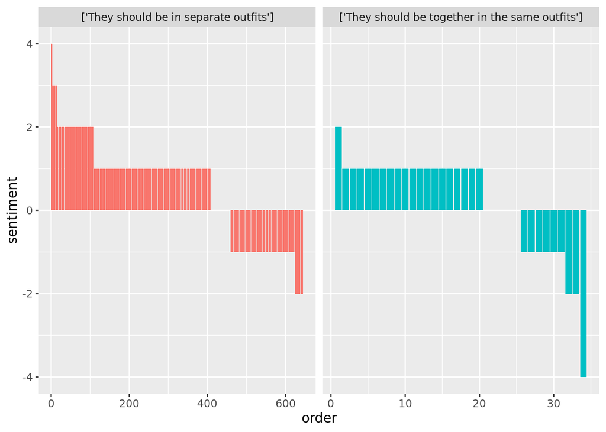

```r
group1 <- s32_bing %>%
  filter(racial_group == "white" & response_type == "short" & outfits == "['They should be in separate outfits']") %>%
  arrange(desc(sentiment));
group1$order <- 1:nrow(group1);

group2 <- s32_bing %>%
  filter(racial_group == "white" & response_type == "short" & outfits == "['They should be together in the same outfits']") %>%
  arrange(desc(sentiment));
group2$order <- 1:nrow(group2);

rbind(group1, group2) %>%
ggplot(., aes(x = order, y = sentiment, fill = outfits)) +
geom_col(show.legend = FALSE) +
facet_wrap(~outfits, ncol = 2, scales = "free_x")
```

Compare AFINN sentiments of long responses for white and Black soldiers.

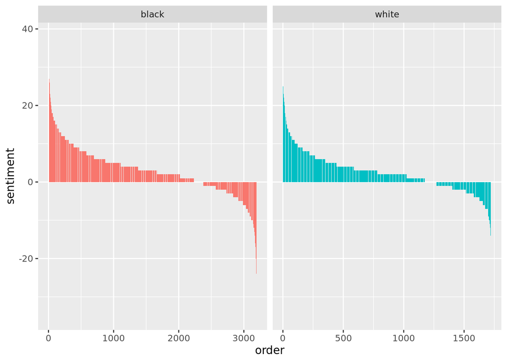

```r
black_long <- s32_afinn %>%
  filter(racial_group == "black" & response_type == "long") %>%
  arrange(desc(sentiment));
black_long$order <- 1:nrow(black_long);

white_long <- s32_afinn %>%
  filter(racial_group == "white" & response_type == "long") %>%
  arrange(desc(sentiment));
white_long$order <- 1:nrow(white_long);

rbind(black_long, white_long) %>%
ggplot(., aes(x = order, y = sentiment, fill = racial_group)) +
geom_col(show.legend = FALSE) +
facet_wrap(~racial_group, ncol = 2, scales = "free_x")
```

Compare AFINN sentiments of long responses for white segregationist and integrationist soldiers.

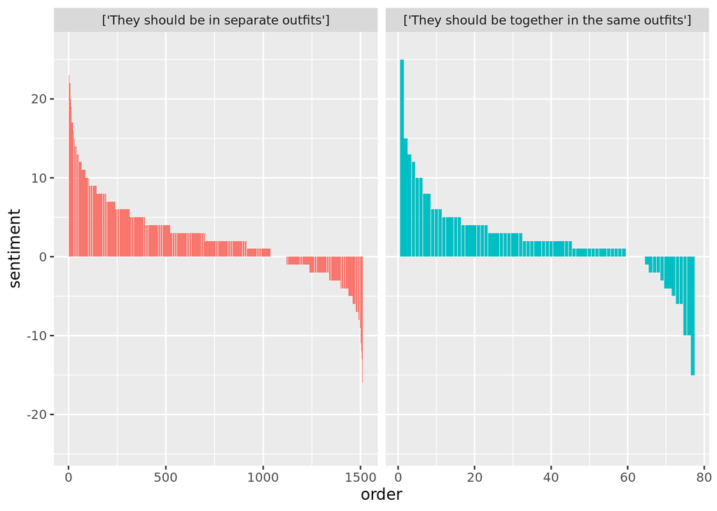

```r
group1 <- s32_afinn %>%
  filter(racial_group == "white" & response_type == "long" & outfits == "['They should be in separate outfits']") %>%
  arrange(desc(sentiment));
group1$order <- 1:nrow(group1);

group2 <- s32_afinn %>%
  filter(racial_group == "white" & response_type == "long" & outfits == "['They should be together in the same outfits']") %>%
  arrange(desc(sentiment));
group2$order <- 1:nrow(group2);

rbind(group1, group2) %>%
ggplot(., aes(x = order, y = sentiment, fill = outfits)) +
geom_col(show.legend = FALSE) +
facet_wrap(~outfits, ncol = 2, scales = "free_x")
```

## NRC Lexicon

The NRC lexicon uses a dictionary to associates a word with the following sentiments: positive, negative, anger, anticipation, disgust, fear, joy, sadness, surprise, and trust. The sentiment of a body of text equals the number of words contributing to that sentiment. A word may contribute to multiple sentiments, yet each word is weighted equally in its contribution.

```r
# read in the data
# data <- read.csv("../../data/s32_neg_bigrams_removed.csv") %>% subset(select = -c(X));
data <- data.table::copy(s32);
```

```r
nrc_sentiments <- get_sentiments("nrc")

# compute sentiments for each response
tmp <- data %>%
  unnest_tokens(word, text) %>%
  inner_join(nrc_sentiments)
```

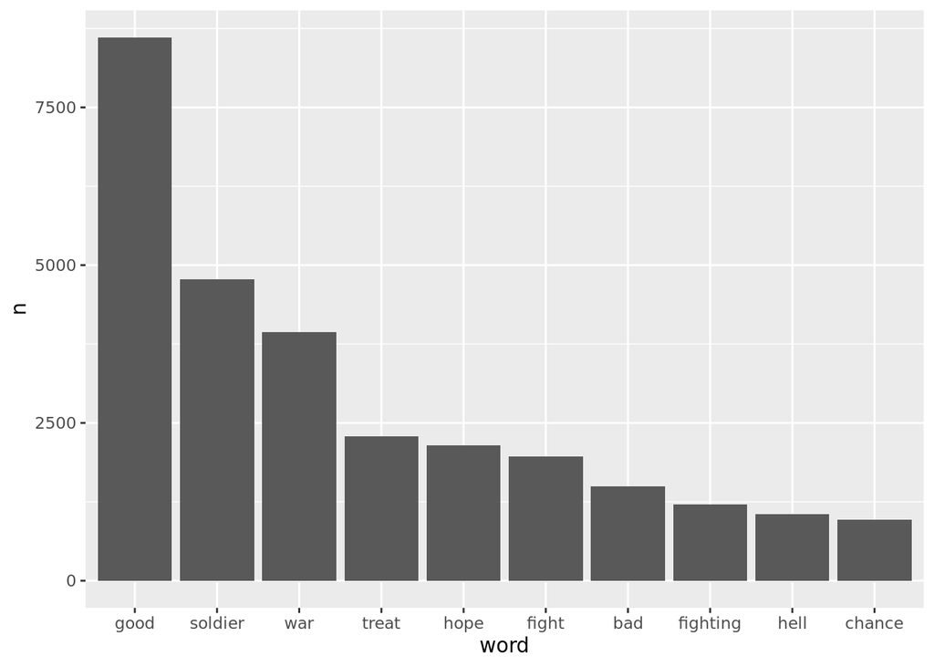

```r
plot_words <- function(sentiment) {
  plot_data <- tmp %>%
  filter(sentiment == sentiment) %>%
  count(word, sort = TRUE) %>%
  top_n(10)

  # use to set order of words
  plot_data$word <- factor(plot_data$word, levels = plot_data$word)
  plot_data %>%
    ggplot(., aes(x = word, y = n)) +
    geom_bar(stat = "identity")
}

plot_words("positive")
```

```r
tmp %>%
  filter(sentiment == "negative") %>%
  count(word, sort = TRUE) %>%
  top_n(10)
```

```
## # A tibble: 10 x 2
##    word           n
##    <chr>      <int>
##  1 war         1971
##  2 fight        656
##  3 fighting     603
##  4 bad          300
##  5 treat        229
##  6 government   223
##  7 hell         212
##  8 combat       165
##  9 damn         156
## 10 unfair       113
```

```r
tmp %>%
  filter(sentiment == "joy") %>%
  count(word, sort = TRUE) %>%
  top_n(10)
```

```
## # A tibble: 10 x 2
##    word        n
##    <chr>   <int>
##  1 good     1722
##  2 hope      430
##  3 food      277
##  4 treat     229
##  5 freedom   165
##  6 kind      156
##  7 god       150
##  8 money     136
##  9 pay       116
## 10 present   109
```

```r
tmp %>%
  filter(sentiment == "fear") %>%
  count(word, sort = TRUE) %>%
    top_n(10)
```

```
## # A tibble: 10 x 2
##    word           n
##    <chr>      <int>
##  1 war         1971
##  2 fight        656
##  3 bad          300
##  4 treat        229
##  5 government   223
##  6 hell         212
##  7 combat       165
##  8 god          150
##  9 change       122
## 10 defense      111
```

```r
tmp %>%
  filter(sentiment == "disgust") %>%
  count(word, sort = TRUE) %>%
    top_n(10)
```

```
## # A tibble: 10 x 2
##    word               n
##    <chr>          <int>
##  1 bad              300
##  2 treat            229
##  3 hell             212
##  4 damn             156
##  5 unfair           113
##  6 sick             111
##  7 discrimination    93
##  8 feeling           92
##  9 hate              84
## 10 boy               80
```

```r
tmp %>%
  filter(sentiment == "anticipation") %>%
  count(word, sort = TRUE) %>%
    top_n(10)
```

```
## # A tibble: 10 x 2
##    word            n
##    <chr>       <int>
##  1 good         1722
##  2 time          907
##  3 hope          430
##  4 long          311
##  5 treat         229
##  6 god           150
##  7 money         136
##  8 opportunity   126
##  9 pay           116
## 10 defense       111
```

```r
tmp %>%
  filter(sentiment == "anger") %>%
  count(word, sort = TRUE) %>%
  top_n(10)
```

```
## # A tibble: 10 x 2
##    word         n
##    <chr>    <int>
##  1 soldier   1593
##  2 fight      656
##  3 fighting   603
##  4 bad        300
##  5 treat      229
##  6 hell       212
##  7 combat     165
##  8 damn       156
##  9 money      136
## 10 unfair     113
```

```r
tmp %>%
  filter(sentiment == "trust") %>%
  count(word, sort = TRUE) %>%
  top_n(10)
```

```
## # A tibble: 10 x 2
##    word        n
##    <chr>   <int>
##  1 good     1722
##  2 hope      430
##  3 officer   307
##  4 food      277
##  5 united    273
##  6 treat     229
##  7 freedom   165
##  8 school    157
##  9 kind      156
## 10 show      156
```

```r
tmp %>%
  filter(sentiment == "surprise") %>%
  count(word, sort = TRUE) %>%
  top_n(10)
```

```
## # A tibble: 10 x 2
##    word        n
##    <chr>   <int>
##  1 good     1722
##  2 chance    963
##  3 hope      430
##  4 treat     229
##  5 money     136
##  6 present   109
##  7 break     108
##  8 deal       92
##  9 feeling    92
## 10 leave      87
```

```r
tmp %>%
  filter(sentiment == "sadness") %>%
  count(word, sort = TRUE) %>%
  top_n(10)
```

```
## # A tibble: 10 x 2
##    word               n
##    <chr>          <int>
##  1 soldier         1593
##  2 bad              300
##  3 treat            229
##  4 hell             212
##  5 unfair           113
##  6 sick             111
##  7 die              110
##  8 discrimination    93
##  9 feeling           92
## 10 leave             87
```

```r
sentiments <- tmp %>%
  group_by(index, racial_group, response_type, outfits, sentiment) %>%
  count() %>%
  spread(sentiment, n, fill = 0)

# normalize sentiments by the number of words contributing to that sentiment
sentiments <- sentiments %>%
  mutate(word_count = anger + anticipation + disgust + fear + joy + negative + positive + sadness + surprise + trust) %>%
  filter(word_count > 0) %>%
  mutate(anger = anger / word_count,
            anticipation = anticipation / word_count,
            disgust = disgust / word_count,
            fear = fear / word_count,
            joy = joy / word_count,
            negative = negative / word_count,
            positive = positive / word_count,
            sadness = sadness / word_count,
            surprise = surprise / word_count,
            trust = trust / word_count)
```

```r
# black, long reponse
black_long_mean <- dplyr::as_data_frame(sentiments) %>%
  filter(racial_group == "black" & response_type == "long") %>%
  select(c("anger",
           "anticipation",
           "disgust",
           "fear",
           "joy",
           "negative",
           "positive",
           "sadness",
           "surprise",
           "trust")) %>%
  summarise_all(mean)
bl_mean_melted <- melt(black_long_mean)
```

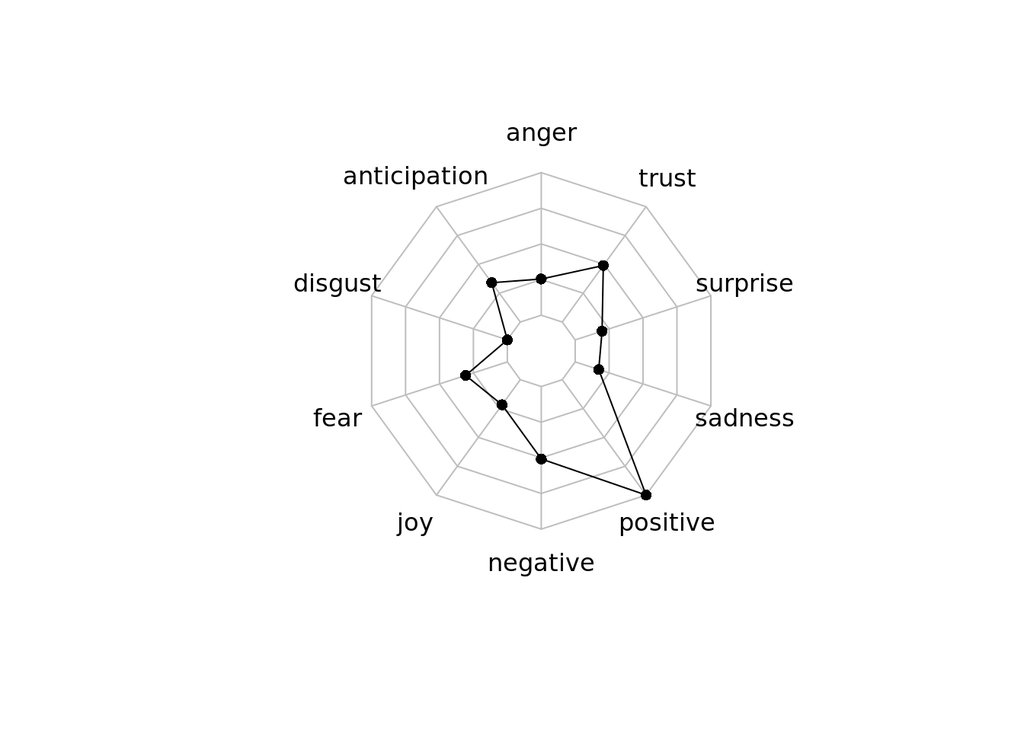

```r
plot_data <- rbind(rep(max(bl_mean_melted$value), 10), rep(min(bl_mean_melted$value), 10), black_long_mean)

radarchart(plot_data,
           cglcol = "grey",
           cglty = 1)
```

```r
white_long_mean <- dplyr::as_data_frame(sentiments) %>%
  filter(racial_group == "white" & response_type == "long") %>%
  select(c("anger",
           "anticipation",
           "disgust",
           "fear",
           "joy",
           "negative",
           "positive",
           "sadness",
           "surprise",
           "trust")) %>%
  summarise_all(mean)

wl_mean_melted <- melt(white_long_mean)
```

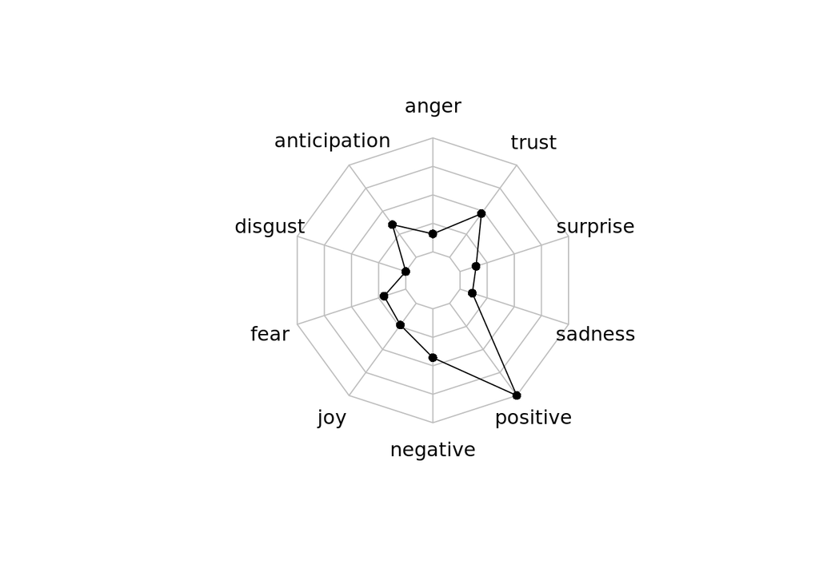

```r
plot_data <- rbind(rep(max(wl_mean_melted$value), 10), rep(min(wl_mean_melted$value), 10), white_long_mean)

radarchart(plot_data,
           cglcol = "grey",
           cglty = 1)
```

```r
black_long <- copy(black_long_mean)
white_long <- copy(white_long_mean)

# combine repsonses
long <- rbind(black_long, white_long)
rownames(long) <- c("Black", "white")
```

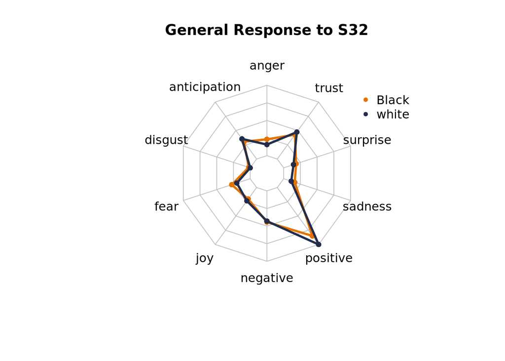

```r
# get min and max for plotting
long_melted <- melt(long)
minval <- min(long_melted$value)
maxval <- max(long_melted$value)

plot_data <- rbind(rep(maxval, 10), rep(minval, 10), long)

colors <- c("#e57200", "#232d4b")

radarchart(plot_data,
           cglcol = "grey", # color of net
           cglty = 1, # net line type
           pcol = colors, # line color
           cglwd = 1, # net width,
           plwd = 3, # line width
           plty = 1, # plot line type
)
legend(x= 1, y= 1, legend = rownames(plot_data)[-c(1,2)], bty = "n", pch = 20, col = colors );
title(main = "General Response to S32");
```

```r
# against desegregation
ws_against <- sentiments %>%
  filter(racial_group == "white" & response_type == "short") %>%
  filter(outfits == "['They should be in separate outfits']")

# for desegregation
ws_for <- sentiments %>%
  filter(racial_group == "white" & response_type == "short") %>%
  filter(outfits == "['They should be together in the same outfits']")

against_mean <- dplyr::as_data_frame(ws_against) %>%
  select(c("anger",
           "anticipation",
           "disgust",
           "fear",
           "joy",
           "negative",
           "positive",
           "sadness",
           "surprise",
           "trust")) %>%
  summarise_all(mean)

for_mean <- dplyr::as_data_frame(ws_for) %>%
  select(c("anger",
           "anticipation",
           "disgust",
           "fear",
           "joy",
           "negative",
           "positive",
           "sadness",
           "surprise",
           "trust")) %>%
  summarise_all(mean)

comb <- rbind(against_mean, for_mean)
rownames(comb) <- c("segregationist", "integrationist")
```

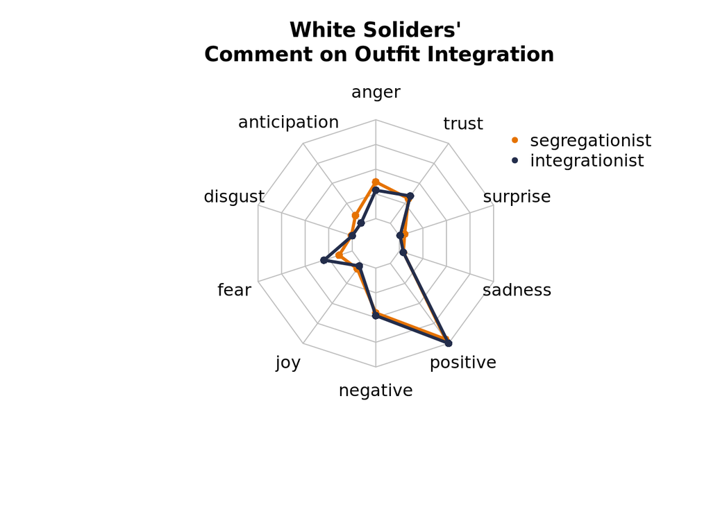

```r
# get min and max for plotting
comb_melted <- melt(comb)
minval <- min(comb_melted$value)
maxval <- max(comb_melted$value)

plot_data <- rbind(rep(maxval, 10), rep(minval, 10), comb)

colors <- c("#e57200", "#232d4b")

radarchart(plot_data,
           cglcol = "grey",
           cglty = 1,
           pcol = colors,
           plty = 1,
           plwd = 3, # line width
);

legend(x = 1, y = 1, legend = rownames(plot_data)[-c(1,2)], bty = "n", pch = 20, col = colors);
title(main = "White Soliders'\n Comment on Outfit Integration");
```

## Gender

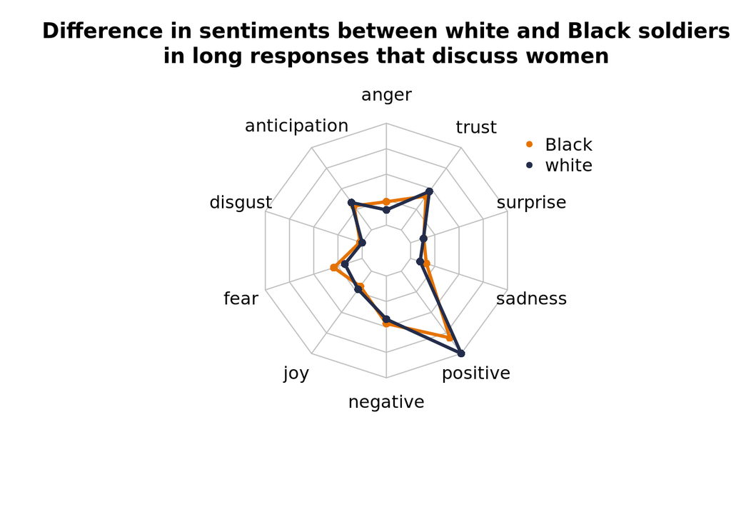

```r
radar2(s32_gender_sentiments,
       group1 = c("black", "long", "Black"),
       group2 = c("white", "long", "white"),
       title = "Difference in sentiments between white and Black soldiers\nin long responses that discuss women");
```

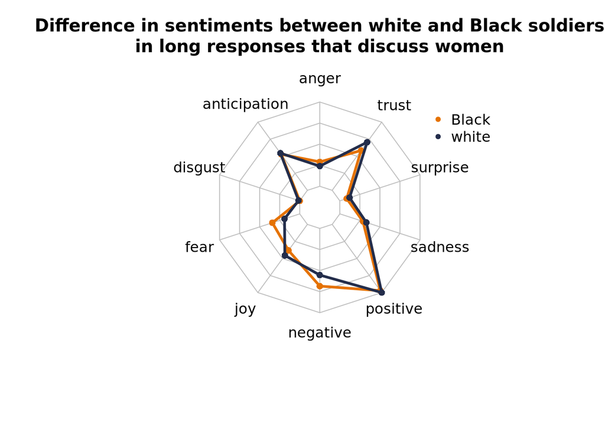

```r
radar2(s32_female_sentiments,
       group1 = c("black", "long", "Black"),
       group2 = c("white", "long", "white"),
       title = "Difference in sentiments between white and Black soldiers\nin long responses that discuss women");
```

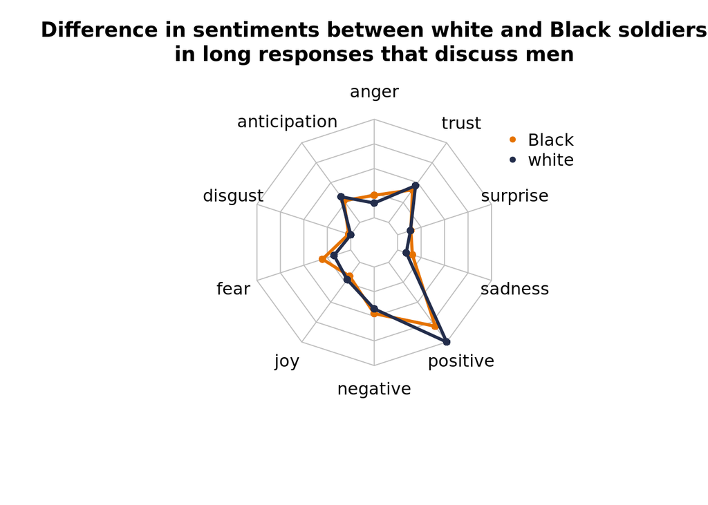

```r
radar2(s32_male_sentiments,
       group1 = c("black", "long", "Black"),
       group2 = c("white", "long", "white"),
       title = "Difference in sentiments between white and Black soldiers\nin long responses that discuss men");
```

```r
gender_words %>% filter(category == "relation")
```

```
##              gender category
## 1            engage relation
## 2           engaged relation
## 3       intercourse relation
## 4          marriage relation
## 5           married relation
## 6             marry relation
## 7              rape relation
## 8               sex relation
## 9        sweetheart relation
## 10 sexual relations relation
## 11             wife relation
## 12            wives relation
```

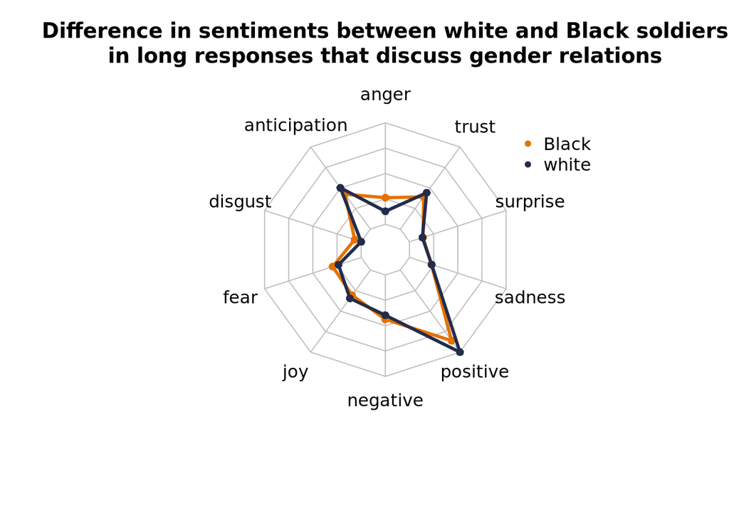

```r
radar2(s32_relation_sentiments,
       group1 = c("black", "long", "Black"),
       group2 = c("white", "long", "white"),
       title = "Difference in sentiments between white and Black soldiers\nin long responses that discuss gender relations");
```

difference in sentiments between white and Black soldiers that use gendered words related to females or relations in their long responses

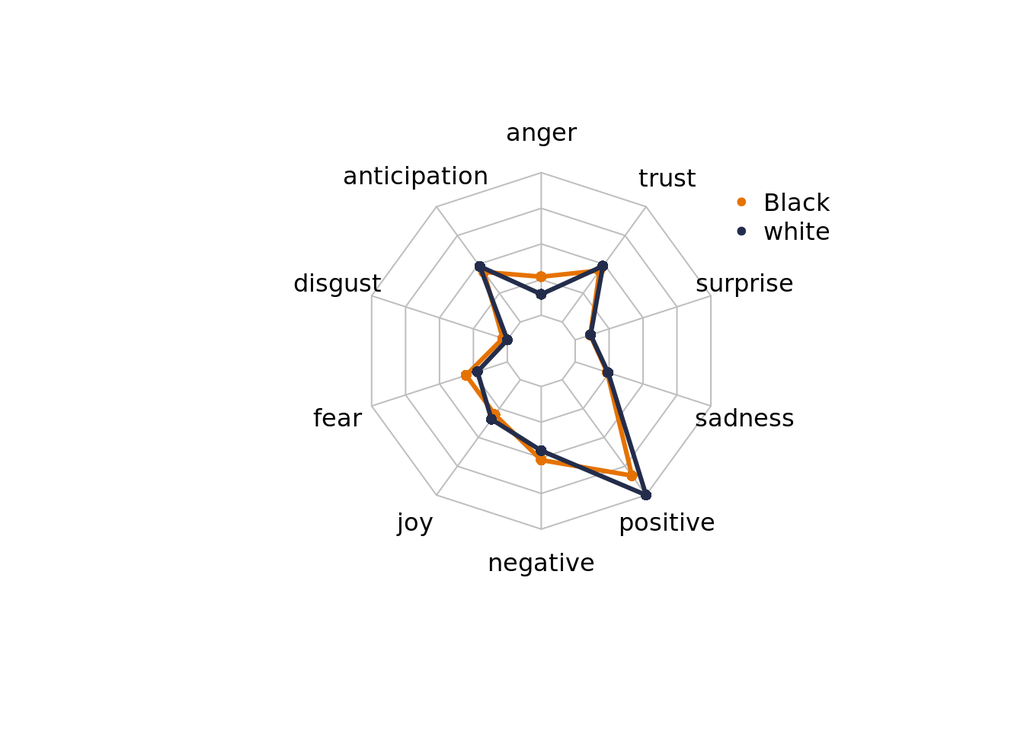

```r
radar2(s32_female_and_relation_sentiments,
       group1 = c("black", "long", "Black"),
       group2 = c("white", "long", "white"),
       title = "");
```